# **Principles of Data Science Tasks to Perform**

# Association and Group Differences Analysis

## Quantitative-Quantitative

Visaulizing quantitative features against each other - Year of Registration, Mileage on Price.

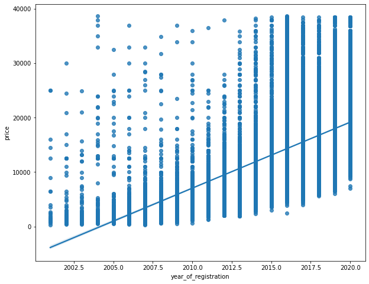

```python
#Plotting year of registration against price
plt.figure(figsize=(10,8))
sns.regplot(data=final_data, x="year_of_registration", y="price");
#there is a positive correlation between year of registration and price
```

From the chart above **there is a positive correlation between year of registration and price.** As we can see the regression line moving upwards.

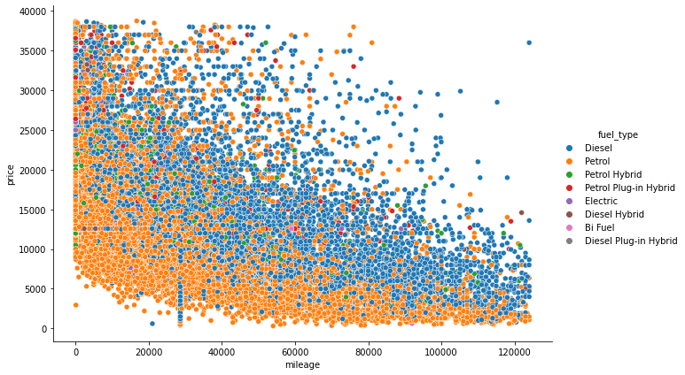

```python
#Plotting mileage against price using fuel type as differentiating factor.
sns.relplot(data=final_data, x="mileage", y="price", hue="fuel_type", height=6, aspect=1.5);
```

From the chart above we can see the relationship between price and mileage.

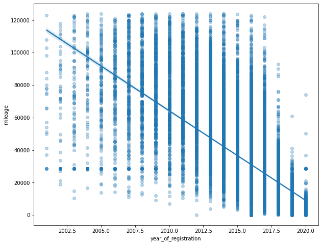

```python
#Plotting year of registration against price
plt.figure(figsize=(10,8))
sns.regplot(data=final_data, x='year_of_registration', y='mileage', scatter_kws=dict(alpha=0.3));
#this shows a negative correlation between year of registration and mileage
```

From the chart above **there is a negative correlation between year of registration and mileage.** As we can see the regression line moving downwards.

## Quantitative-Categorical

Doing some visaulization on quantitative features against categorical features

1. Grouping the data by year of registration against the price

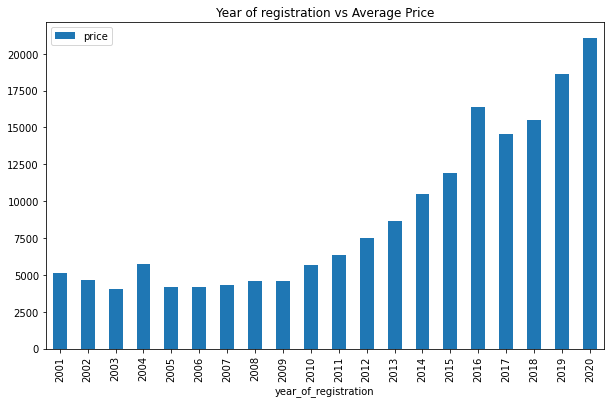

```python
#using groupby on year and plotting against price.
df1 = pd.DataFrame(final_data.groupby(['year_of_registration'])['price'].mean())
df1.plot.bar(figsize=(10, 6))
plt.title('Year of registration vs Average Price')
plt.show()
```

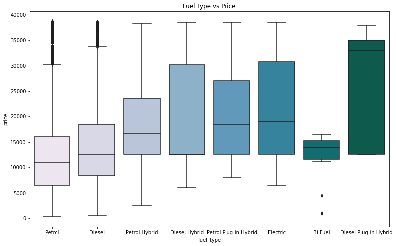

```python
#Plotting fuel type against price to see the relationship with price
plt.figure(figsize=(13,8))
plt.title('Fuel Type vs Price')
sns.boxplot(x=final_data['fuel_type'], y=final_data['price'], palette='PuBuGn');
```

The box plot chart shows that **diesel plug-in hybrid price spreads** more than other fuel types and the **bi-fuel fuel type vehicle has a less spread of price.** This makes the **diesel plug-in fuel type vehicle more expensive** on the list **as oppose to Bi-Fuel fuel type vehicle**

1. Is there a relationship between standard make, model and body type against price?

```python
final_data['standard_make'].value_counts() # to view the most popular vehicle maker in the data set
```

```
BMW              1849
Audi             1739
Volkswagen       1690
Vauxhall         1625
Mercedes-Benz    1557
                 ...
Replica             1
Morgan              1
Dax                 1
Proton              1
TVR                 1
Name: standard_make, Length: 63, dtype: int64
```

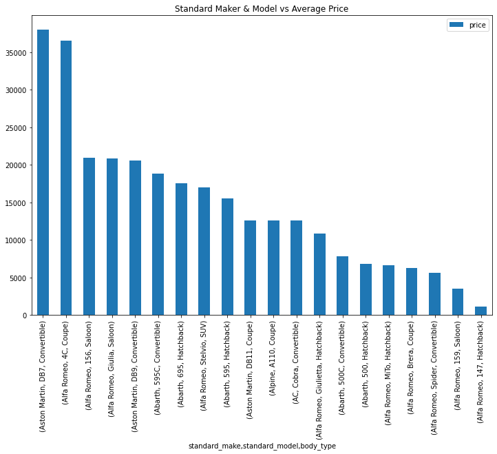

```python
#Plotting standard make, model and body type to see the relationship with price
df = pd.DataFrame(final_data.groupby(['standard_make', 'standard_model', 'body_type'])['price'].mean().head(20).sort_values(ascending=False))
df.plot.bar(figsize=(12, 8))
plt.title('Standard Maker & Model vs Average Price')
plt.show()
```

```python
final_data[(final_data['standard_make'] == 'Aston Martin') & (final_data['standard_model'] == 'DB7')]
```

|  | mileage | standard_colour | standard_make | standard_model | vehicle_condition | year_of_registration | price | body_type | crossover_car_and_van | fuel_type | age | price_cat |
| --- | --- | --- | --- | --- | --- | --- | --- | --- | --- | --- | --- | --- |
| 381432 | 29600.0 | Grey | Aston Martin | DB7 | USED | 2004 | 37995.0 | Convertible | False | Petrol | 2 | Luxury |

1. Is there anything interesting in colour and price?

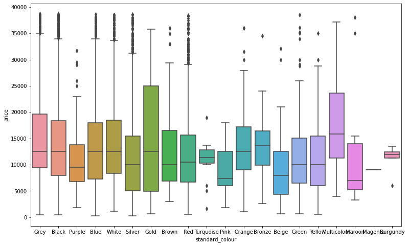

```python
#Plotting to see how colour of vehicle relates with price
plt.figure(figsize=(13,8))
sns.boxplot(x=final_data['standard_colour'], y=final_data['price']);
```

1. How about standard colour and make against price?

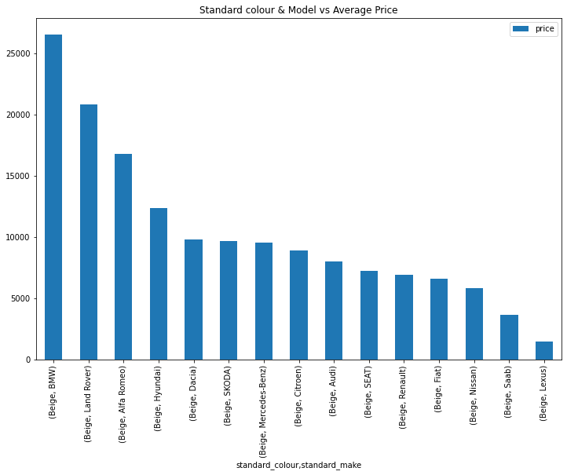

```python
#Plotting to see how standard colour & model of vehicle relates with price
df2 = pd.DataFrame(final_data.groupby(['standard_colour', 'standard_make'])['price'].mean().head(15).sort_values(ascending=False))
df2.plot.bar(figsize=(12, 8))
plt.title('Standard colour & Model vs Average Price')
plt.show()
```

1. How does body type of vehicle relates with prce?

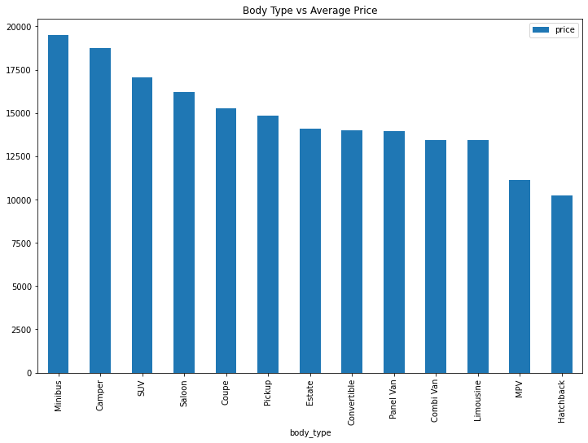

```python
#Plotting body type to see the relationship with price
df3 = pd.DataFrame(final_data.groupby([ 'body_type'])['price'].mean().head(20).sort_values(ascending=False))
df3.plot.bar(figsize=(12, 8))
plt.title('Body Type vs Average Price')
plt.show()
```

Minibus body type vehicle has higher price, while the hatchback has a lower price.

1. How does the engineered feature - age (mileage age) relate with price?

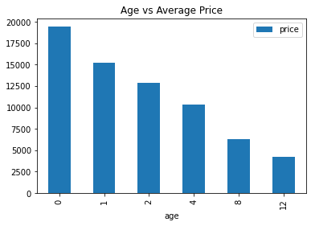

```python
#plotting age against price
df4 = pd.DataFrame(final_data.groupby(['age'])['price'].mean())
df4.plot.bar();
plt.title('Age vs Average Price')
plt.show()
```

The plot showing **age (age engineered from mileage)** show clearly that **vehicle with low age are higher in price** while a **higher age makes a less price.** *This can be considered as a good predictor for price.*